# ARMA Estimation

Doynikov A

Август 2, 2021

В этой лекции рассмотрим возможные методы решения задачи оценки параметров ARMA модели по наблюдениеям за процессом $y_1,...,y_N$

# Метод моментов

Это простейший метод оценки и достаточно эффективный для моделей AR(p).
$$x_t=\phi_1x_{t-1}+...+\phi_px_{t-p}+\epsilon_t$$
Умножаем левую и правую часть на $x_{t-k}$ и берем математическое ожидание( отсюда происходит название метода)

$$E(x_{t-k}x_t)=\phi_1E(x_{t-k}x_{t-1})+...+\phi_pE(x_{t-k}x_{t-p})+E(x_{t-k}\epsilon_t)$$

Полагая $k = 1,...,p$, и , разделив на дисперсию $E(x_{t}x_{t})$ получаем систему уравнений Юла-Уокера.

$\phi_1+\rho_1\phi_2+.......+\rho_{p-1}\phi_p=\rho_1$

$\rho_1\phi_1+\phi_2+.......+\rho_{p-2}\phi_p=\rho_2$

$...................$

$\rho_{p-1}\phi_1+\rho_{p-2}\phi_2+.......+\phi_p=\rho_p$

По наблюдениям $x_1,...,x_N$ оценим автокорреляционную функцию
$$\rho_k=\frac{\sum_{t=1}^{N-k}(x_t-Ex)(x_{t+k}-Ex)}{(N-k)D[x]}$$
. Подставим $\rho_k$ в уравнения, получим систему линейных алгебраических уравнений Юла-Уокера. Решения $\widehat{\phi}_1,...,\widehat{\phi}_p$ называют оценками Юла-Уокера это оценки метода моментов.
Однако в случае моделей скользящего среднего метод не очень удобен. Для примера рассмотрим простейшую MA(1) модель.
$$x_t =
\epsilon_t+\theta\epsilon_{t-1}$$

Если также умножить на $x_{t-1}$ и взять математическое ожидание получим формулу
$$\rho_1=-\frac{\theta}{1+\theta^2}$$
Для нахождения оценки $\widehat{\theta}$ необходимо решить квадратное уравнение. Корни которого

$-\frac{1}{\rho_1} \pm \sqrt{\frac{1}{4\rho_1^2}-1}$

Нетрудно убедиться, что произведение корней равно 1, но только один из корней удовлетворяет условию обратимости $|\theta|>1$, а именно

$\widehat{\theta}=\frac{-1+\sqrt{1-4\rho_1^2}}{2\rho_1}$

При $\rho_1=\pm0.5$ действительное решение существует и равно $\pm1$, но оно необратимо. Если $|\rho_1|>0.5$ действительных решений нет. И метод моментов не работает без дополнительных ограничений $|\rho_1|<0.5$ При оценке модели произвольного порядка ограничения на $\rho_k$ становятся очень сложными, громоздкими и это крайне неудобно. В силу этих причин метод моментов редко используют при оценке моделей скользящего среднего и смешаных моделей и ,наоборот, он крайне эффективен при оценке AR(p) моделей В случае оценки смешаных моделей также получим трудно проверяемые условия для обратимости модели.

### Оценка дисперсии шума

Сначала оценивается $c_k=D[y_t]$. Оценкой для $c_k$ будет

$s^2=\frac{1}{n-1}\sum_{t=1}^n(y_t-\overline{y})^2$

Затем используется известное соотношение для AR(p) моделей

$\widehat{\sigma}_{\epsilon}^2=(1-\widehat{\phi}_1\rho_1-... -\widehat{\phi}_p\rho_p)s^2$

В случае MA(q) соотношение

$\widehat{\sigma}_{\epsilon}^2=\frac{s^2}{1+\widehat{\theta}_1^2+...+\widehat{\theta}_q^2}$

```r
library("TSA")
```

```r
estimate.ma1.mom=function(x){r=acf(x,plot=F)$acf[1];
if (abs(r)<0.5) return((-1+sqrt(1-4*r^2))/(2*r))
else return(NA)}
data(ma1.2.s); data(ma1.1.s)
estimate.ma1.mom(ma1.2.s); estimate.ma1.mom(ma1.1.s)
```

```
## [1] -0.5554273
```

```
## [1] 0.7196756
```

# Метод наименьших квадратов

### Модель авторегрессии

Для примера рассмотрим модель первого порядка с константой

$y_t-\mu= \phi(y_{t-1}-\mu)+\epsilon_t$

Суть метода в нахождении параметров, минимизирующих сумму квадратов ошибок

$S(\phi,\mu)=\sum_{t=2}^n(y_t-\mu-\phi(y_{t-1}-\mu))^2$

Эту сумму иногда называют условной суммой квадратов ошибок. Вычислим частные производные $\partial S(\phi,\mu)/\partial\phi=0$,$\partial S(\phi,\mu)/\partial\mu=0$ и приравняем их нулю. Разрешая полученные уравнения относительно $\phi$ и $\mu$ получим

$\widehat{\phi}=\frac{\sum_{t=2}^n(y_t-\overline{y})(y_{t-1}-\overline{y})}{\sum_{t=2}^n(y_{t-1}-\overline{y})^2}$

$\widehat{\mu}=\overline{y}$

Для AR(p) процесса произвольного порядка оценка константы $\widehat{\mu}= overline{y}$ останется такой же. Явные выражения для $\phi_1,...,\phi_p$ имеют более сложный вид, но численно легко вычисляются. Хорошей аппроксимацией этих оценок являются оценки Юла-Уокера.

Напомним основные теоремы (Фишера и Рао) о свойствах оценок наименьших квадратов Если предоположить независимость и нормальность распределения ошибок $\epsilon_t\sim N(0,\sigma^2)$ то Rao в 1974 году доказал, что $c′\tilde\beta$ имеет минимальную дисперсию не только в классе всех линейных несмещенных оценок, но и в классе всех несмещенных оценок (эффективность). В этом случае также оценка максимального правдоподобия совпадает с оценкой наименьших квадратов. В случае не нормальности рапределения ошибок условия при которых оценка наименьших будет является ассимпототически эффективной найдены были Cox в 1968 году.

Дополнительно будем предполагать нормальность и независимость ошибок $\epsilon_{i} \sim N(0,\sigma^2) или \epsilon∼N(0,I_{n}\sigma^2)$

Теорема 2.Если $Y\sim N(X\beta,I_{n}\sigma^2)$ , тогда

1. $\tilde\beta \sim N(\beta,\sigma^2(X′X)^{-1})$
2. $(\tilde\beta-\beta)′X′X\tilde(\beta-\beta)/\sigma^2∼\chi^2$
3. $\tilde\beta$ не зависит от $s^2$ как случайные величины
4. $RSS/\sigma^2=(n-p)s^2/\sigma^2∼\chi_{n-p}²$

### Модели скользящего среднего

Рассмотрим на примере модели MA(1)

$y_t=\epsilon_t-\theta\epsilon_{t-1}$

Перепишем модель

$\epsilon_t= y_t+\theta\epsilon_{t-1}$

положим $\epsilon_0=0$ Последовательно вычислим для некоего заданного $\theta$

$\epsilon_1=y_1$

$\epsilon_2=y_2+\theta\epsilon_1$

$...$

$\epsilon_n=y_n+\theta\epsilon_{n-1}$

Далее вычислим $S(\theta)=\sum_{t=1}^n(\epsilon_t)^2$ и вычислим ее минимум по $\theta$, используя метод минимизации Ньютона-Гаусса или какой-нибудь другой.

Для произвольного порядка модели используется тот же подход. Задав нулями первые q начальных значений $\epsilon_k=0,k \ne q$ последовательно вычислим

$\epsilon_t=y_t+\theta_1\epsilon_{t-1}+...+\theta_q\epsilon_{t-q}, q \le t\le n$

вычислим $S(\theta_1,...,\theta_q)=\sum_{t=1}^n(\epsilon_t)^2$ и вычислим ее минимум по $\theta_1,...\theta_q$, используя метод многомерной минимизации

### Cмешаные модели

Аналогичный подход применяют в смешаных моделях. Например модель ARMA(1,1).Запишем ее в виде

$\epsilon_t=y_t-\phi y_{t-1}+\theta\epsilon_{t-1}$

Зададим нулями необходимые начальные значения, последовательно получим все $\epsilon_t$. Вычислим $S(\phi,\theta)=\sum_{t=1}^n$ и применим подходящий метод минимизации.

# Метод максимального правдоподобия и безусловный наименьших квадратов

Здесь будем предполагать, что необходимое число начальных значений задано нулями $\epsilon_p=\epsilon_{p-1}=...=\epsilon_{p+1-q}= 0$

### Метод максимального правдоподобия

Для любых наблюдений $y_1,...,y_n$ функция правдоподобия $L$ определяется как совместная плотность вероятностей реально полученных наблюдений и рассматривается как функция от неизвестных параметров $\phi,\theta,\mu,\sigma_{\epsilon}^2$. Значения параметров $\phi,\theta,\mu,\sigma_{\epsilon}^2$ при которых функция $L$ принимает максимальное значение (наиболее правдоподобно) называют оценками максимального правдоподобия. Начнем с AR(1) модели. Наиболее часто предполагаеся, $\epsilon_1,...\epsilon_t$ независимы и нормально распределенные случайные величины. Совместная плотность распределения для $\epsilon_2,...\epsilon_t$

$f(\epsilon_2,...\epsilon_t)=(2\pi\sigma_{\epsilon}^2)^{-(n-1)/2}exp(-\frac{1}{2\sigma_{\epsilon}^2}\sum_{t=2}^n\epsilon_t^2)$

Для модели AR(1) с константой $\mu$

$y_2-\mu=\phi(y_1-\mu)+\epsilon_2$

$y_3-\mu=\phi(y_2-\mu)+\epsilon_3$

$...$

$y_n-\mu=\phi(y_{n-1}-\mu)+\epsilon_n$

Последние выражения суть линейное преобразование между $\epsilon_2,...\epsilon_t$ и $y_2,...,y_n$ якобиан преобразования равен 1 Следовательно совместная плотность распределения при условии заданного $y_1$

$f(y_2,..,y_n|y_1)=(2\pi\sigma_{\epsilon}^2)^{-(n-1)/2}exp(-\frac{1}{2\sigma_{\epsilon}^2}\sum_{t=2}^n[(y_t-\mu)- \phi(y_{t-1}-\mu)]^2)$

$y_1$ имеет нормальное распределение с мат.ожиданием $\mu$ и с дисперсий $\frac{\sigma_{\epsilon}^2}{(1-\phi)^2}$ умножая условную плотность на плотность распределения $y_1$ получим совместное распределение $y_1,...,y_n$, которая и есть искомая функция правдоподобия

$L(\phi,\nu)=(2\pi\sigma_{\epsilon}^2)^{-n/2}(1-\phi^2)exp[-\frac{1}{2\sigma_{\epsilon}^2}S(\phi,\mu)]$

где

$S(\phi,\mu)=\sum_{t=2}^n[(y_t-\mu)- \phi(y_{t-1}-\mu)]^2)+(1-\phi^2)(y_1-\mu)$

Сумма выше называется безусловной суммой квадратов. Как правило, перед тем как максимизировать, берут логарифм функции правдоподобия.

Для процесса AR(1) логарифм функции правдоподобия

$ln(L(\phi,\nu)=-n/2ln(2\pi)-n/2ln(\sigma_{\epsilon}^2)+1/2ln(1-\phi^2)-\frac{1}{\sigma_{\epsilon}^2}S(\phi,\mu)$

для которого численно находят максимум. Параметры $\hat{\phi},\hat{\mu}$ на которых максимум достигается и есть искомые оценки максимального правдоподобия. Еще один параметр, по которому ищется максимум это $\sigma_{epsilon}^2$. Нетрудно убедиться, что максимум $ln(L(\phi,\nu)$ достигается при

$\hat{\sigma}_{epsilon}^2=\frac{S(\hat{\phi},\hat{\mu})}{n}$

### Безусловный метод наименьших квадратов

Сравнивая с условным методом наименьших квадратов, замечаем, что должны минимизироваить $S_c(\phi\nu)$ условную сумму наименьших квадратов и безусловную $S(\phi\nu)$, которая оличается от условной на член $(1-\phi^2)(y_1-\mu)$, который входит в сумму нелинейно. Поэтому минимизация $S_c(\phi\nu)$ проводят численно и полученные оценки называют безусловными оценками наименьших квадратов. Они достаточно близки к условным оценкам наименьших квадратов.

## Cвойства оценок

Без доказательства примем следующий факт. При стремлении размера выборки к бесконечности оценки максимального правдоподобия, оценки условного и безусловного метода наименьших квадратов статистически эквивалентны. Оценки максимального правдоподобия, вообще говоря, могут быть смещёнными (см. примеры), но являются состоятельными, асимптотически эффективными и асимптотически нормальными оценками. Асимптотическая нормальность означает, что $\sqrt {n}(\hat{\theta}-\theta) \xrightarrow d N(0,\boldsymbol{I}^{-1}_{\infty})$ здесь $\theta=(\phi,\mu)$ - вектор параметров, а $\boldsymbol{I}^{-1}_{\infty}$ асимптотическая ковариационная матрица оценок

## Моделирование и оценивание моделей. Примеры

Моделирование модели ARMA(1,1)

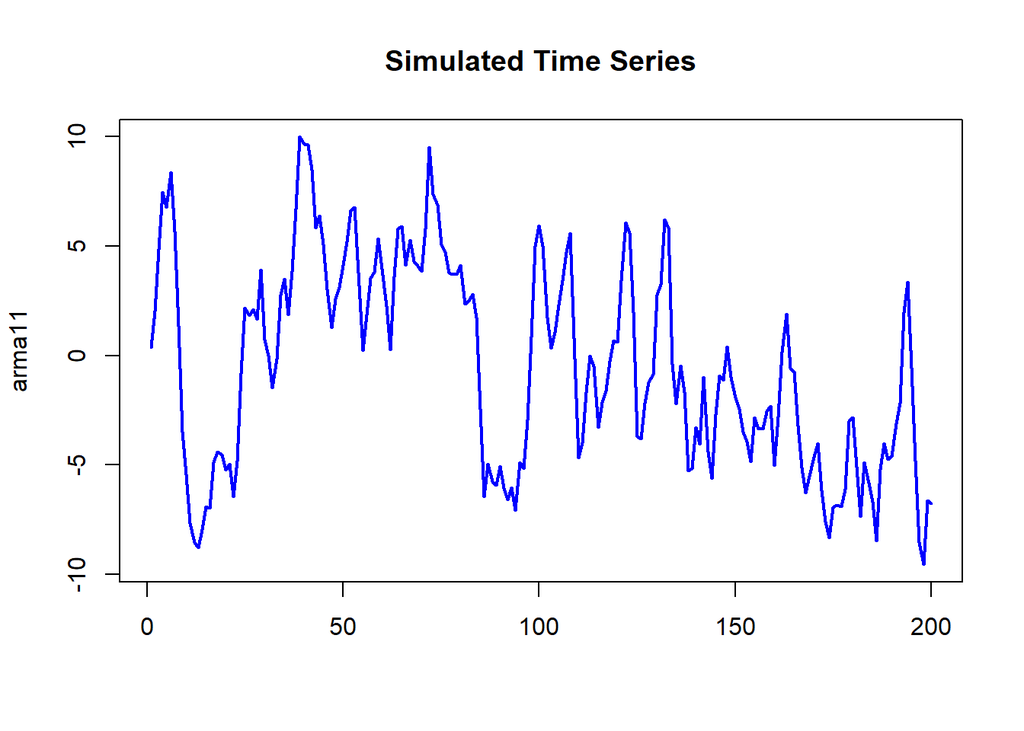

```r
phi1 <- 0.8
theta1 <- 0.4
sigma <- 2
model <- list(ar = phi1,ma = theta1)
arma11 <- arima.sim(model=model,n = 200,innov=rnorm(200,0,sd=sigma))
matplot(arma11,lwd=2,type="l",col="blue",main="Simulated Time Series")
```

Оценка методом максимального правдоподобия

```r
ml1 <- arima(arma11,order = c(1,0,1),method="ML")
ml1$coef
```

```
##        ar1        ma1  intercept
##  0.8474426  0.3857978 -0.6442615
```

```r
ml1$sigma2
```

```
## [1] 3.442194
```

Условный метод наименьших квадратов

```r
css1 <- arima(arma11,order = c(1,0,1),method="CSS")
css1$coef
```

```
##        ar1        ma1  intercept
##  0.8519850  0.3863734 -0.6784818
```

```r
css1$sigma2
```

```
## [1] 3.460168
```

Метод моментов (только для AR(p) моделей) с автоматическим выбором порядка модели по критерию Акаике

```r
ar1 <- ar(arma11,method="yule-walker")
ar1 <- ar(arma11,method="yw")
ar1$order
```

```
## [1] 2
```

```r
ar1$ar
```

```
## [1]  1.2216298 -0.3562203
```

# Анализ остатков

Итак ARMA модель идентифицирована, порядки модели выбраны, модель оценена Возникает вопрос в адекватности построенной модели. О многом могут сказать остатки после удаления оцененной модели

Чаше всего предполагается нормальность белого шума $\epsilon_t$. Конечно можно постоить гистограмму и проверить нормальность остатков обычным путем с помощью критериев Колмогорова и Хи-квадрат. Но здесь будут предложены некоторые критерии специально разработанные для анализа остатков после удаления модели во временных рядах

Остатки после удаления модели.

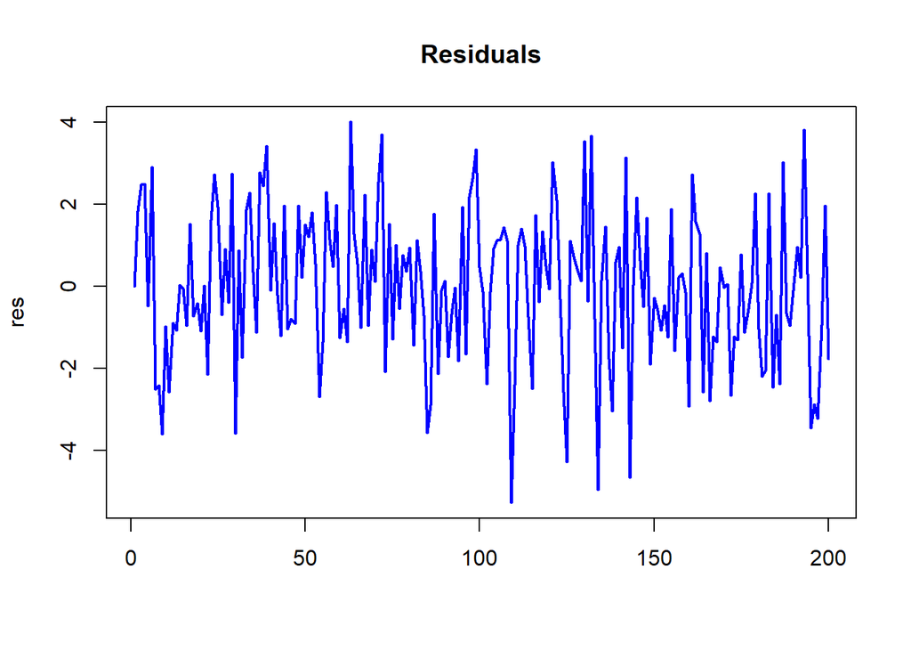

```r
res <- css1$residuals
matplot(res,lwd=2,type="l",col="blue",main="Residuals")
```

Эффективным средством для визуальной проверки нормальности является так называемый QQ-график или квантиль-квантиль график. В нем по одной оси выдаются заданные теоретические например нормальные квантили, по другой оси выдаются выборочные (по эмпирической функции распределение).

Нормальный QQ-график остатков

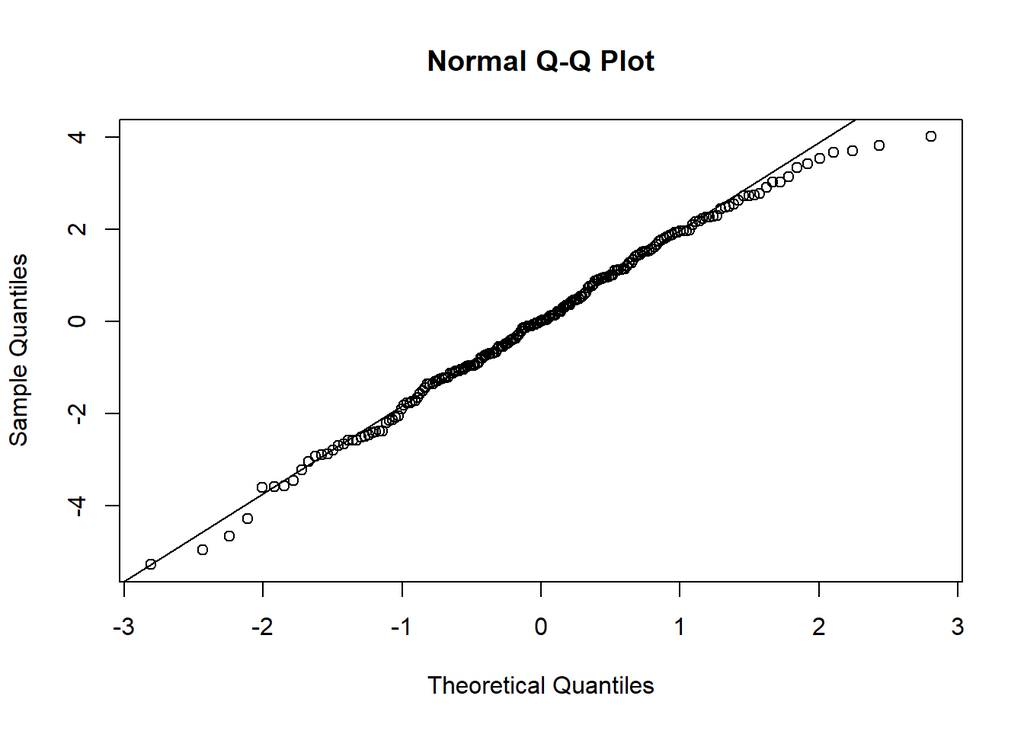

```r
qqnorm(res)
qqline(res)
```

Чтобы увидеть осталась ли в остатках какая нибудь зависимость не учтенная моделью необходимо построить автокорреляционную функцию остатков

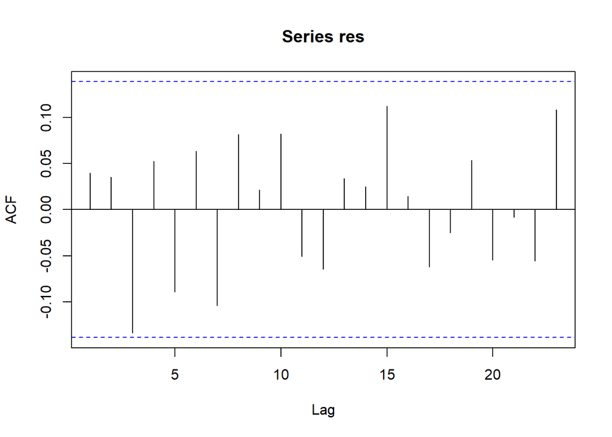

```r
acf(res)
```

### Спектральная плотность ARMA(p,q) процесса

Для процессa ARMA(p,q)
$$\phi(B)x_t=\theta(B)\epsilon_t$$
получен явный вид спектральной плотности процесса.

Для смешаных процессов произвольно порядка спектральную плотность также записывается через характеристические полиномы $\phi(B)$ и $\theta(B)$ и выглядит следующим образом.

$f(\lambda)= |\frac{\theta_q(e^{-2\pi i \lambda})}{\phi_p(e^{-2\pi i \lambda})}|^2\sigma_{\epsilon}^2$

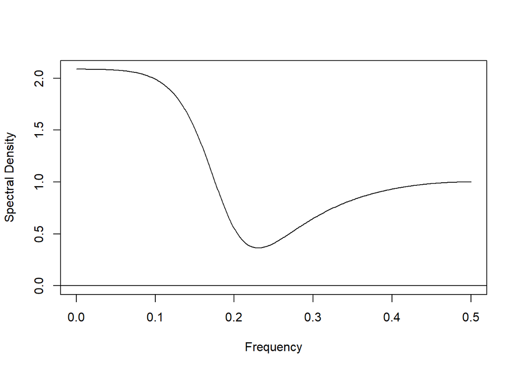

```r
phi_1 = 0.5
phi_2 = -0.4
theta_1 = -0.3
theta_2 = 0.6
ARMAspec(model = list(ar = c(phi_1,phi_2),ma = c(theta_1,theta_2)))
```

## Тест Льюнг-Бокса

При анализе остатков после удаления очень эффективен тест Льюнг-Бокса. Здесь по сути проверяется гипотеза случайности- независимости и одинаковой распределенности, но не в исходных данных, а именно в остатках после удаления модели ARMA, чем и объясняется его полезность.

Основная гипотеза:остатки являются случайными (то есть представляют собой белый шум). Что свидетельствует также , что оцененная ARMA модель адекватна и оно учла все связи в исходных данных. Альтернатива: данные не являются случайными или это означает, что предложенная ARMA модель не адекватна. Статистика критерия:

${\tilde{Q}}=n\left(n+2\right)\sum_{k=1}^m\frac{\hat{\rho}^2_k}{n-k}$,

где $n$— число наблюдений, $\hat{\rho}_k$— автокорреляция k-го порядка, и $m$— число проверяемых лагов(задержек). Если ${\tilde{Q}}>\chi_{1-\alpha,\;m}^2$,

где $\chi_{1-\alpha,\;m}^2$ — квантили распределения хи-квадрат с m степенями свободы, то нулевая гипотеза отвергается и признаётся наличие автокорреляции до m-го порядка во временном ряду.

Пример использования теста Льюнг-Бокса для проверки 6 первых автокорреляций остатков. Число степеней свободы следует задать равной 2, так как мы оценивали модель ARMA(1,1)

```r
  Box.test(res, lag = 6, type = "Ljung-Box", fitdf = 2)
```

```
##
##  Box-Ljung test
##
## data:  res
## X-squared = 7.2766, df = 4, p-value = 0.122
```

Посмотрим на сглаженную переодограмму остатков. Сглаживание производится трехкратной сверткой окна Даниэлла

```r
library(TSA)

k3<- kernel('daniell',c(5,5,5))
sp=spec(res,kernel=k3,log='no',sub='',xlab='Frequency',
ylab='Smoothed Sample Spectral Density',col = "blue",lwd = 2)
```

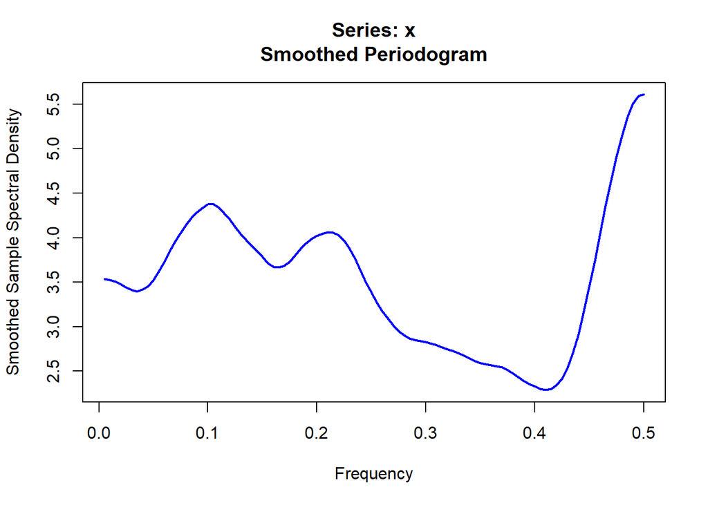

Сравним результаты теста в случае заведомо не адекватной модели

```r
css2 <- arima(arma11,order = c(1,0,0),method="CSS")
res2 <- css2$residuals
Box.test(res2, lag = 6, type = "Ljung-Box", fitdf = 1)
```

```
##
##  Box-Ljung test
##
## data:  res2
## X-squared = 31.716, df = 5, p-value = 6.763e-06
```

Для сравнения построим сглаженную спектральную плотность остатков в заведомо неправильной модели и одновременно выдадим сглаженную пертодограмму правильной модели. Сглаживание производится трехкратной сверткой окна Даниэлла

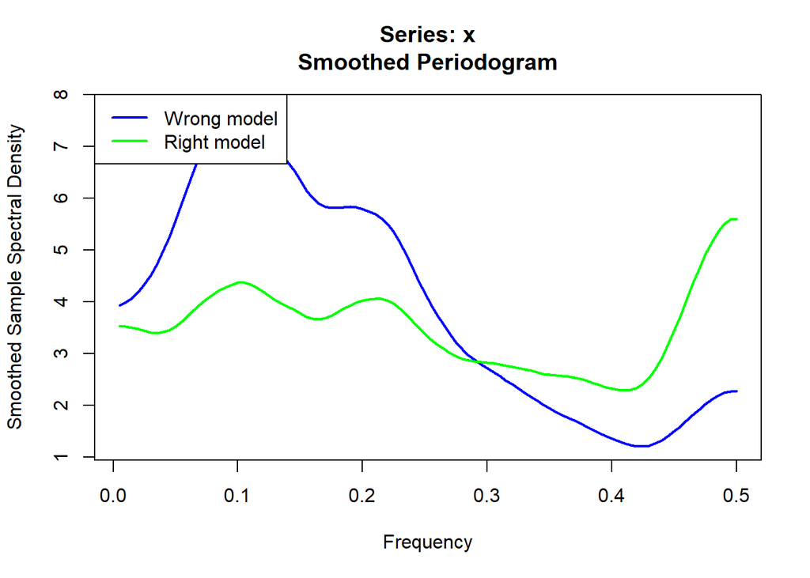

```r
library(TSA)

k3<- kernel('daniell',c(5,5,5))
sp2=spec(res2,kernel=k3,log='no',sub='',xlab='Frequency',
ylab='Smoothed Sample Spectral Density',col = "blue",lwd = 2)
lines(sp$freq,sp$spec,col='green',lwd=2)
legend("topleft",c("Wrong model","Right model"),lwd = 2,col=c("blue","green"))
```

Хорошо видно, что правильная модель имеет спектральную плотность остатков гораздо ближе к белому шуму, чем у заведомо неправильной модели.

## Сравнение моделей. Информационный критерий Хироцуго Акаике

Для сравнения результатов оценки по нескольким моделям и выбора лучшей из них Х.Акаике (1974) был предложен следующий критерий. В общем случае AIC:
$$\mathit{AIC} = 2k -
2\ln(L)\,$$
где $k$ — число параметров в статистической модели, и $L$ — максимизированное значение функции правдоподобия модели.

Будем полагать, что ошибки модели нормально и независимо распределены. Пусть $n$ — число наблюдений и RSS-
$$\mathit{RSS} =
\sum_{i=1}^n \hat{\varepsilon}_i^2$$
, остаточная сумма квадратов. Далее мы предполагаем, что дисперсия ошибок модели неизвестна, но одинакова для всех них. Следовательно:
$$\mathit{AIC}=2k + n[\ln(2\pi \mathit{RSS}/n) +
1]\,$$
. В случае сравнения моделей на выборках одинаковой длины, выражение можно упростить, выкидывая члены зависящие только от n:
$$\mathit{AIC}=2k +
n[\ln(\mathit{RSS})]\,$$
. Таким образом, критерий не только вознаграждает за качество приближения, но и штрафует за использование излишнего количества параметров модели. Считается, что наилучшей будет модель с наименьшим значением критерия AIC.

## Промышленное производство России

Произведем идентификацию ARMA модели к реальным данным ряду промышленного производства России

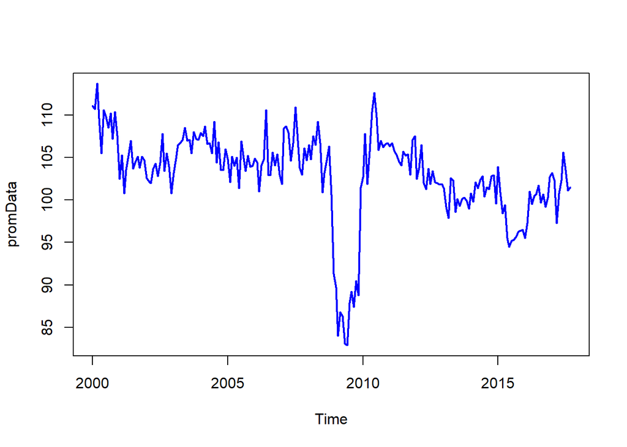

```r
promData <- read.csv("./PromProizv.csv",header = T)
promData <- ts(promData$PromProizv,start= c(2000,1),frequency = 12)
plot.ts(promData,col = "blue",lwd = 2,type = "l")
```

Построим ACF,PACF

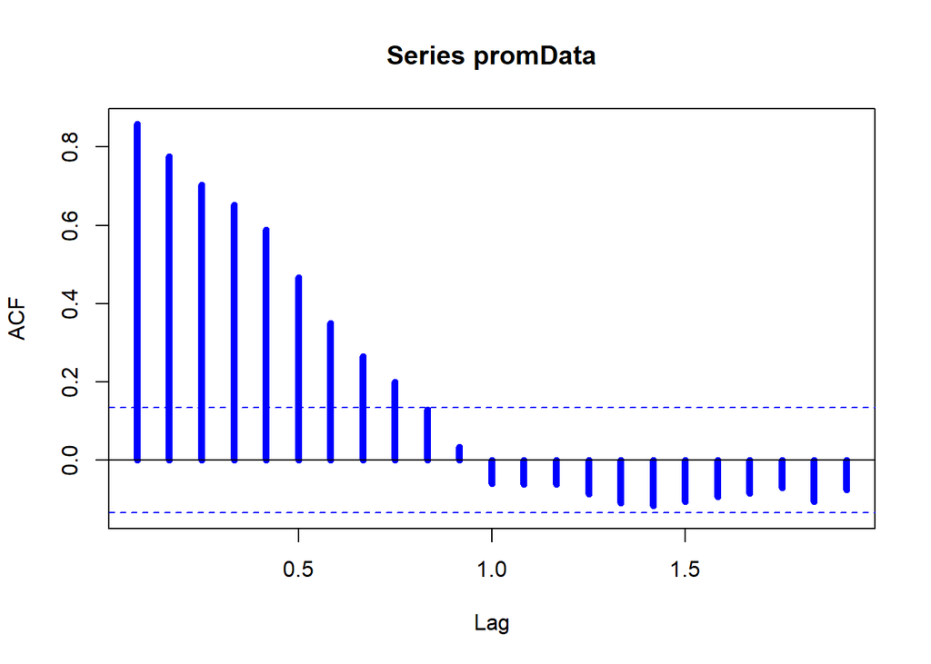

```r
acf(promData,lwd = 5, col = "blue")
```

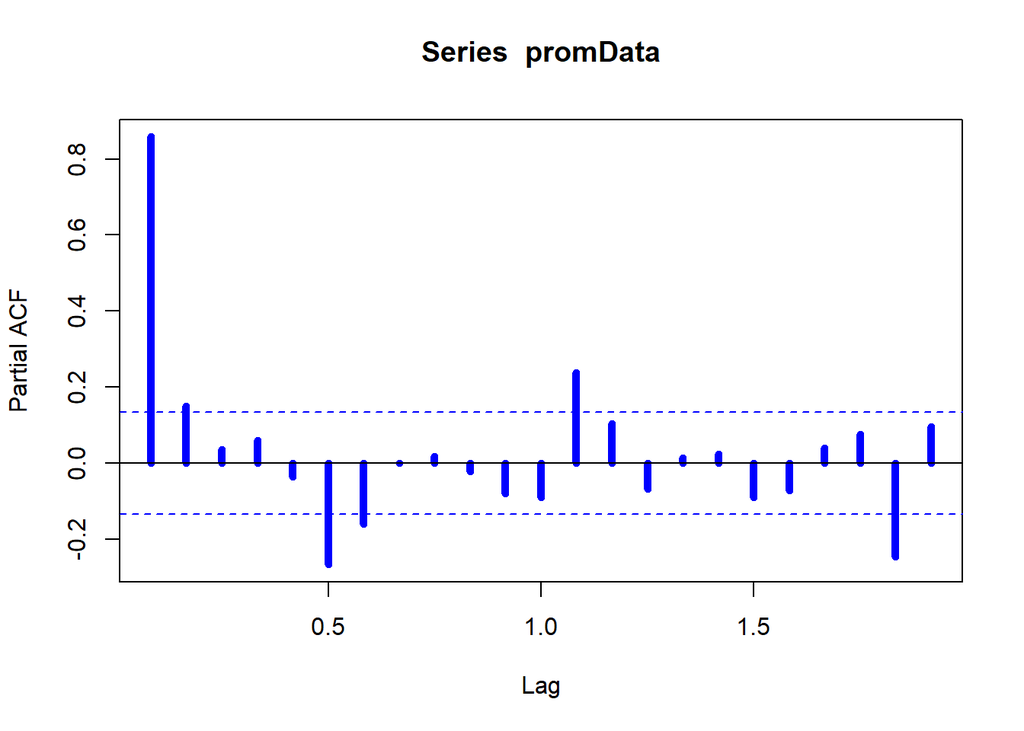

```r
pacf(promData,lwd = 5, col = "blue")
```

Модель можно проидентифицировать как AR(2) или AR(6). Оценим обе модели и сравним результаты.

Попробуем оценить и порядки смешаной модели

```r
library(TSA)
eacf(promData)
```

```
## AR/MA
##   0 1 2 3 4 5 6 7 8 9 10 11 12 13
## 0 x x x x x x x x x o o  o  o  o
## 1 x o o o x o o o o o o  x  o  o
## 2 x o o o x x o o o o o  x  o  o
## 3 x x o o x o o o o o o  x  o  o
## 4 x x o o x o o o o o o  x  o  o
## 5 x x o x x o o o o o o  x  o  o
## 6 x x o o o o o o o o o  x  o  x
## 7 o x o o o o o o o o o  x  o  x
```

Добавим модель ARMA(1,1) к списку наших перспективных моделей

```r
ar2 <-  arima(promData,order = c(2,0,0),method="CSS")
ar2$coef
```

```
##         ar1         ar2   intercept
##   0.7188174   0.1598922 102.5224142
```

```r
ar2$sigma2
```

```
## [1] 6.666835
```

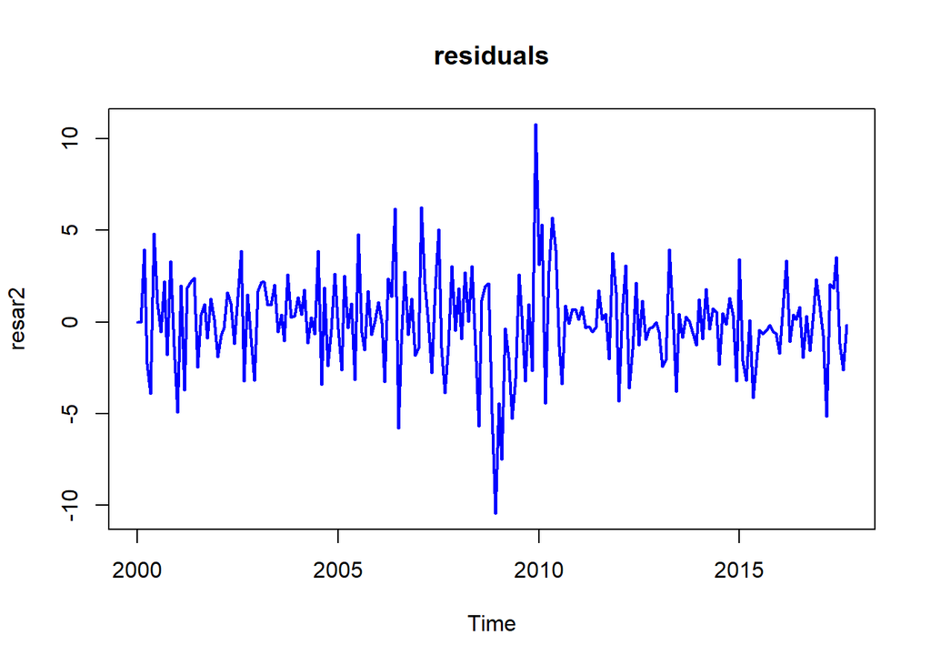

```r
resar2 <- ar2$residuals
plot.ts(resar2,col = "blue",lwd = 2,type = "l", main = "residuals")
```

Оценка ARMA моделей не выдает t-test оценок модели, но его можно посмотреть так

```r
library(lmtest)
coeftest(ar2)
```

```
##
## z test of coefficients:
##
##             Estimate Std. Error z value Pr(>|z|)
## ar1         0.718817   0.067614 10.6312  < 2e-16 ***
## ar2         0.159892   0.067246  2.3777  0.01742 *
## intercept 102.522414   1.464959 69.9831  < 2e-16 ***
## ---
## Signif. codes:  0 '***' 0.001 '**' 0.01 '*' 0.05 '.' 0.1 ' ' 1
```

проведем тест Льюнг-Бокса остатков и постром qq-график

```r
  Box.test(resar2, lag = 12, type = "Ljung-Box", fitdf = 2)
```

```
##
##  Box-Ljung test
##
## data:  resar2
## X-squared = 46.064, df = 10, p-value = 1.397e-06
```

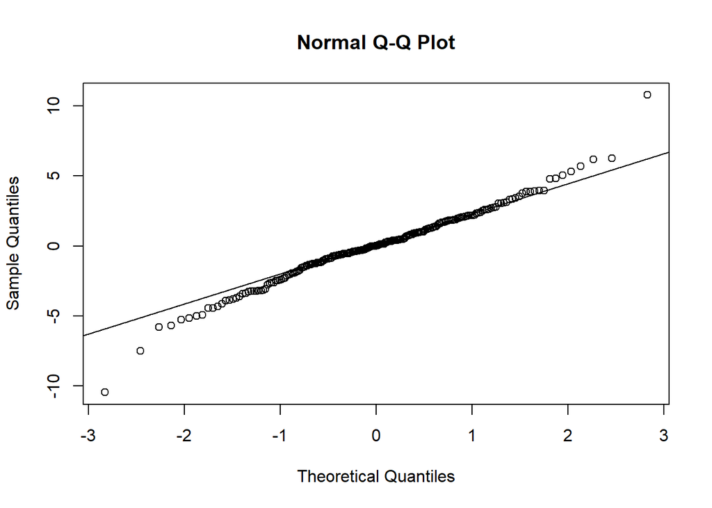

```r
  qqnorm(resar2)
  qqline(resar2)
```

Остатки явно не нормально распределены, имеют очень тяжелые хвосты Построим ACF остатков

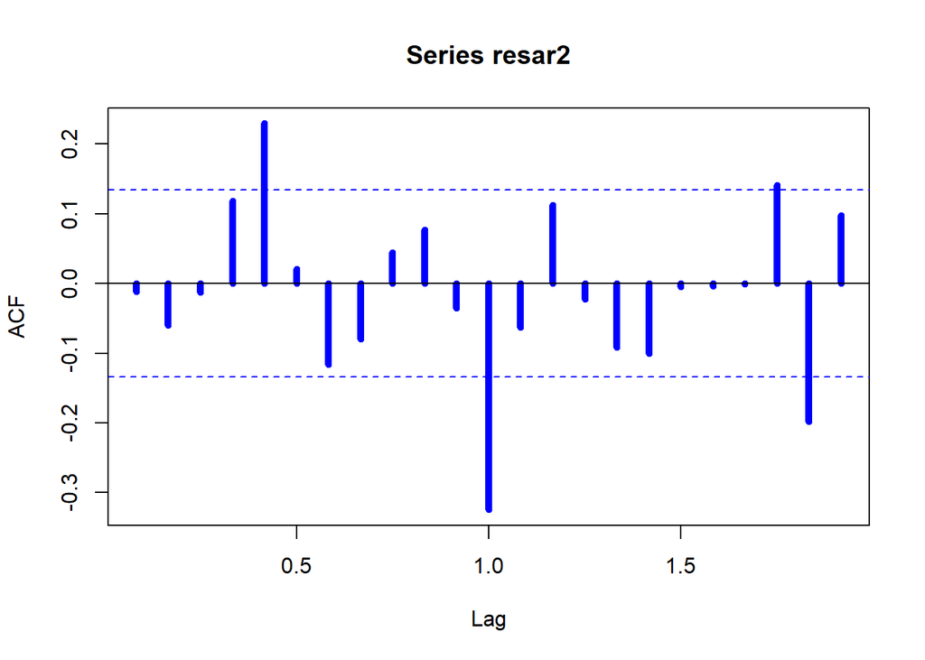

```r
  acf(resar2,lwd = 5, col = "blue")
```

Проделаем то же с моделью 6 порядка

```r
ar6 <-  arima(promData,order = c(6,0,0),method="CSS")
ar6$coef
```

```
##           ar1           ar2           ar3           ar4           ar5
##   0.705719922   0.143473302   0.007128936   0.133682674   0.127997445
##           ar6     intercept
##  -0.261110530 102.615495547
```

```r
ar6$sigma2
```

```
## [1] 5.997954
```

```r
coeftest(ar6)
```

```
##
## z test of coefficients:
##
##              Estimate  Std. Error z value  Pr(>|z|)
## ar1         0.7057199   0.0655172 10.7715 < 2.2e-16 ***
## ar2         0.1434733   0.0799678  1.7941   0.07279 .
## ar3         0.0071289   0.0801547  0.0889   0.92913
## ar4         0.1336827   0.0798621  1.6739   0.09415 .
## ar5         0.1279974   0.0796569  1.6069   0.10809
## ar6        -0.2611105   0.0647906 -4.0301 5.576e-05 ***
## intercept 102.6154955   1.1757354 87.2777 < 2.2e-16 ***
## ---
## Signif. codes:  0 '***' 0.001 '**' 0.01 '*' 0.05 '.' 0.1 ' ' 1
```

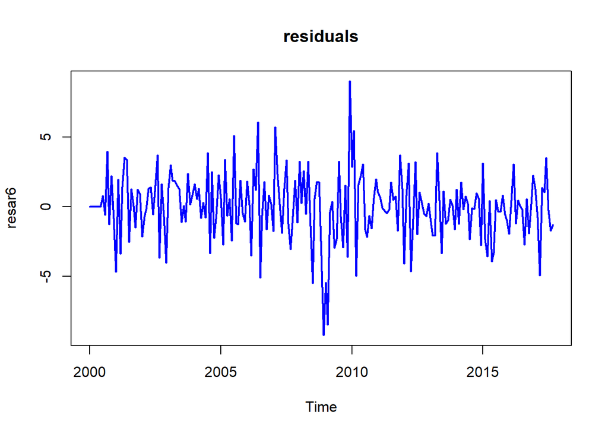

```r
resar6 <- ar6$residuals
plot.ts(resar6,col = "blue",lwd = 2,type = "l", main = "residuals")
```

```r
Box.test(resar6, lag = 12, type = "Ljung-Box", fitdf = 6)
```

```
##
##  Box-Ljung test
##
## data:  resar6
## X-squared = 21.196, df = 6, p-value = 0.001692
```

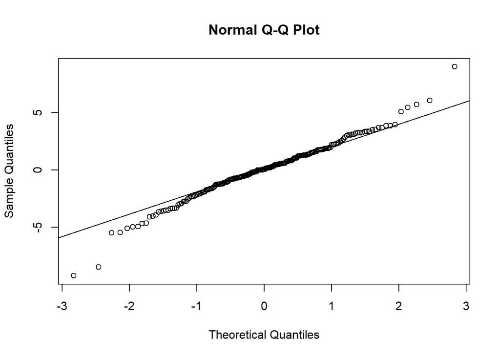

```r
qqnorm(resar6)
qqline(resar6)
```

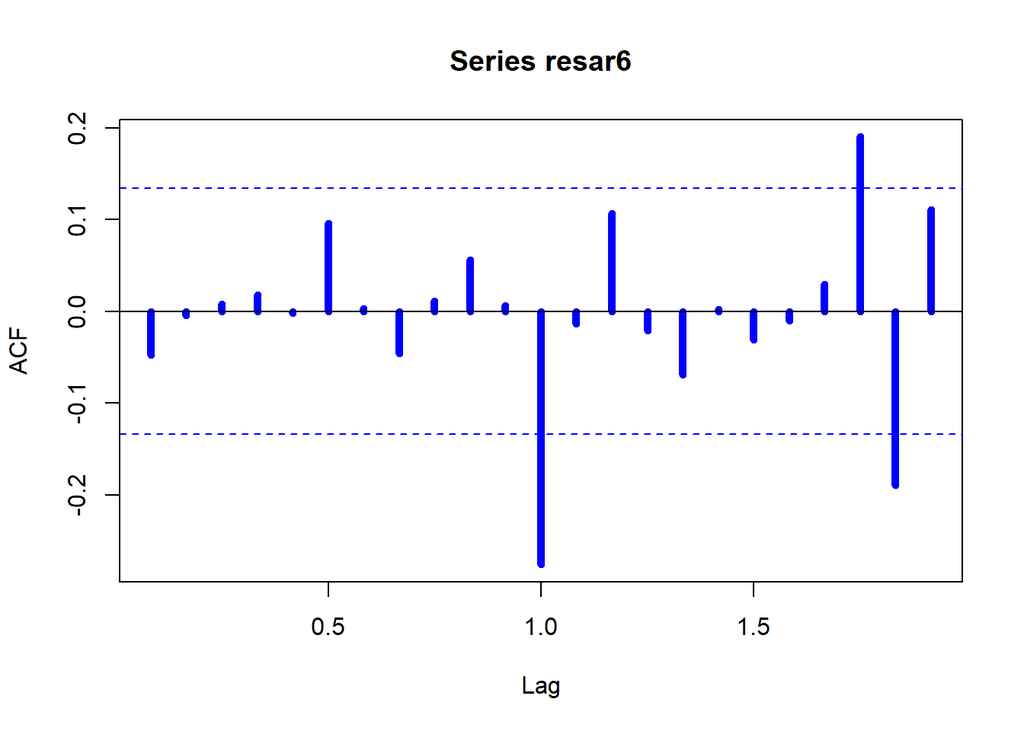

```r
acf(resar6,lwd = 5, col = "blue")
```

Оценим смешаную модель

```r
ar_1_1 <-  arima(promData,order = c(1,0,1),method="CSS")
ar_1_1$coef
```

```
##         ar1         ma1   intercept
##   0.9085941  -0.2065655 102.4803197
```

```r
ar_1_1$sigma2
```

```
## [1] 6.613941
```

```r
coeftest(ar_1_1)
```

```
##
## z test of coefficients:
##
##             Estimate Std. Error z value  Pr(>|z|)
## ar1         0.908594   0.031631 28.7249 < 2.2e-16 ***
## ma1        -0.206566   0.077635 -2.6607  0.007797 **
## intercept 102.480320   1.541514 66.4803 < 2.2e-16 ***
## ---
## Signif. codes:  0 '***' 0.001 '**' 0.01 '*' 0.05 '.' 0.1 ' ' 1
```

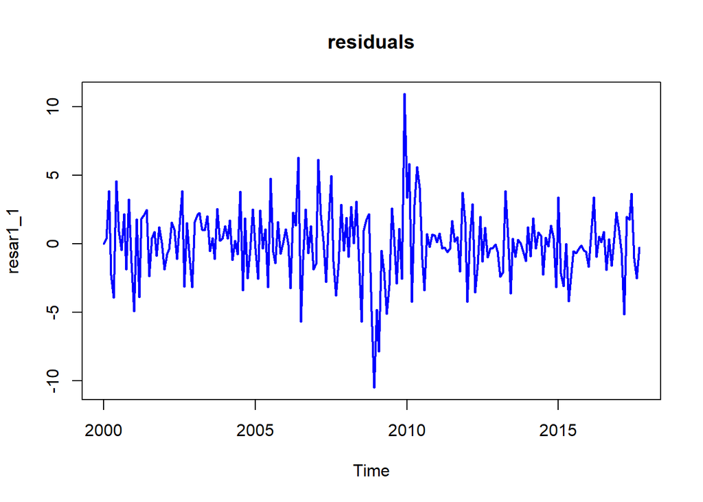

```r
resar1_1 <- ar_1_1$residuals
plot.ts(resar1_1,col = "blue",lwd = 2,type = "l", main = "residuals")
```

```r
Box.test(resar1_1, lag = 12, type = "Ljung-Box", fitdf = 2)
```

```
##
##  Box-Ljung test
##
## data:  resar1_1
## X-squared = 44.739, df = 10, p-value = 2.423e-06
```

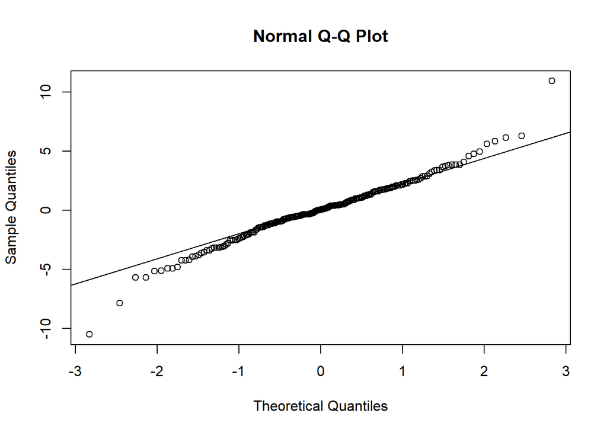

```r
qqnorm(resar1_1)
qqline(resar1_1)
```

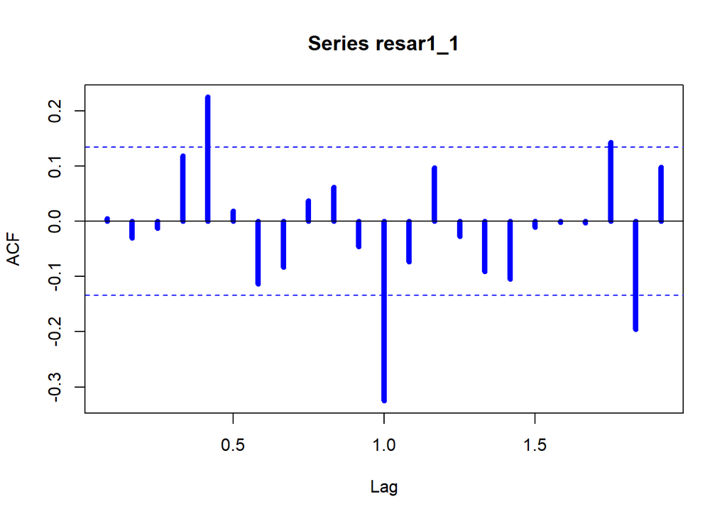

```r
acf(resar1_1,lwd = 5, col = "blue")
```

В результате, модель 6 порядка предпочтительней(тест Льюнг-Бокса). Сравним теперь модели по тесту Акаике. Для этого переоценим модели методом максимального правдоподобия и посмотрим на значения критерия.

```r
ml_ar6 <-  arima(promData,order = c(6,0,0),method="ML")
ml_ar2 <-  arima(promData,order = c(2,0,0),method="ML")
ml_ar1_1 <-  arima(promData,order = c(1,0,1),method="ML")
ml_ar1_1$aic
```

```
## [1] 1015.986
```

```r
ml_ar6$aic
```

```
## [1] 1007.43
```

```r
ml_ar2$aic
```

```
## [1] 1016.603
```

Также получается, что модель AR(6) лучше. Cмешаная модель на втором месте.

Но все модели в остатках нормальности не дают. Требуется дополнительное исследование модели, например можно преобразовать каким-нибудь образом преобрать данные.

Посмотрим на спектры остатков AR6 модели, затем одновременно посмотрим спектр исходных данных и остатков AR6 модели.

```r
sp6=spec(resar6,kernel=k3,log='no',sub='',xlab='Frequency',main = 'Smoothed Sample Spectral Density AR(6)',
col = "green",lwd = 2)
```

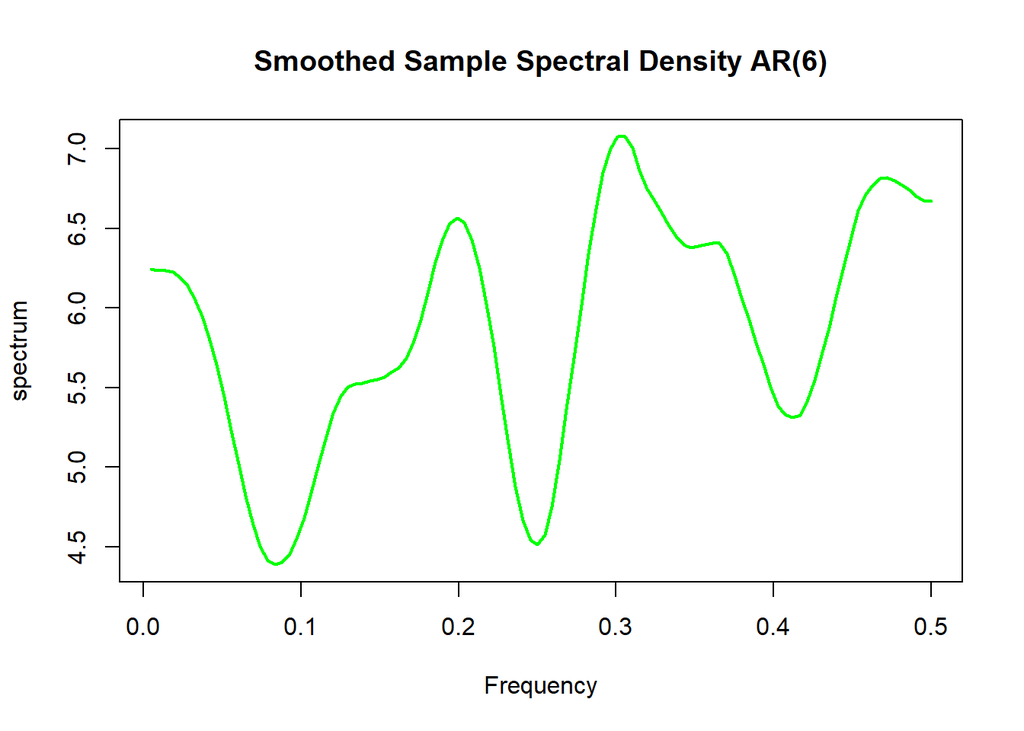

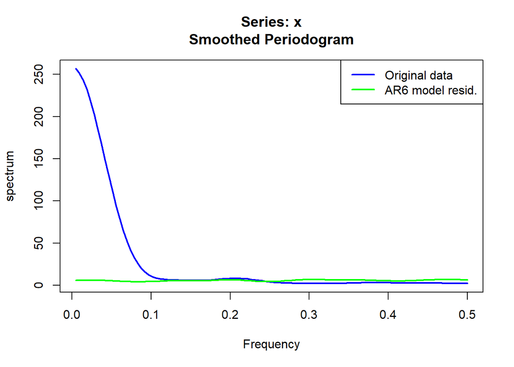

```r
sp=spec(promData,kernel=k3,log='no',sub='',xlab='Frequency',
col = "blue",lwd = 2)

lines(sp6$freq,sp6$spec,col='green',lwd=2)
legend("topright",c("Original data","AR6 model resid."),lwd = 2,col=c("blue","green"))
```

Отдельно построим спектр модели `ar6`

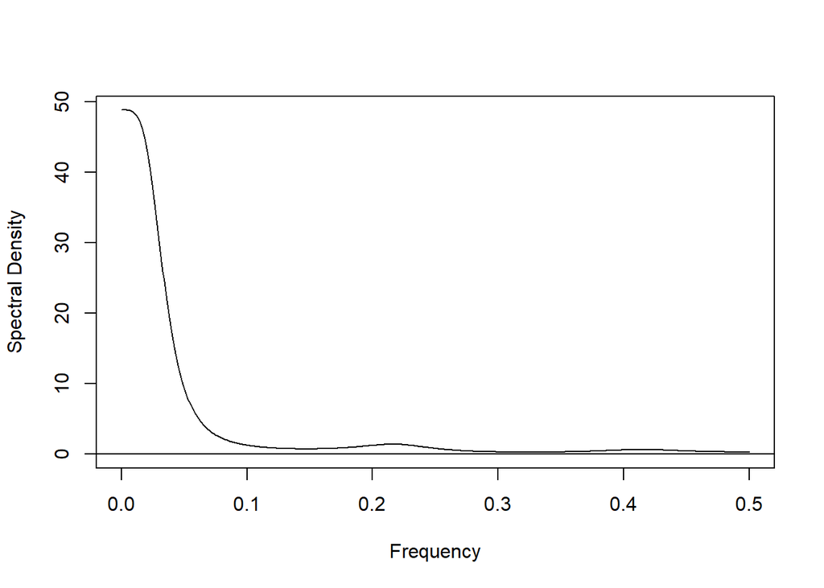

```r
ARMAspec(model = list(ar=ar6$coef[1:6]))
```